# Homework 10

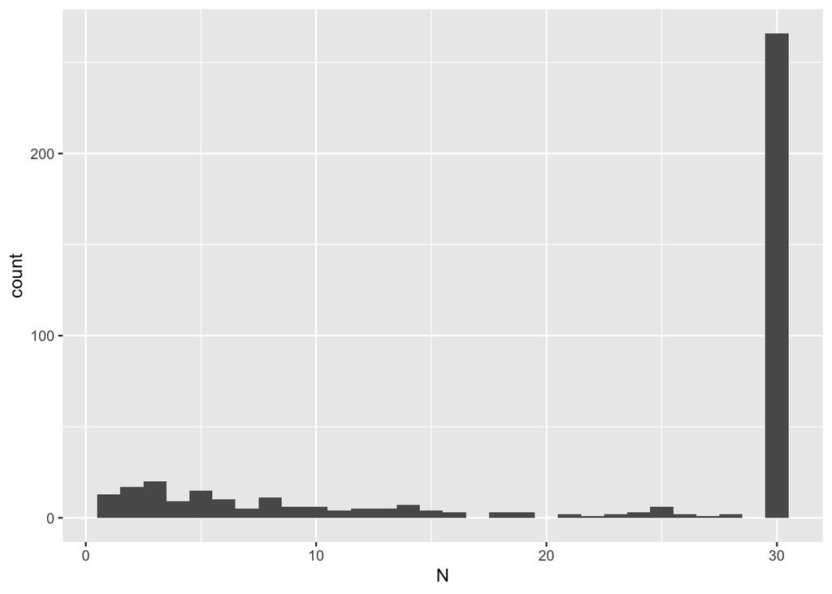

```r
## Each of these subjects should contribute one observation
## to x and one observation to y. Wait... what??? How can we
## have 431 participants and only 422 incongruent
## observations and 414 congruent observations? A good way
## to go about investigating this is to ask how many
## observations in total each subject provides.
dN <- d[, .N, .(subject)][order(N)]
ggplot(data=dN, aes(N)) +
  geom_histogram()
## `stat_bin()` using `bins = 30`. Pick better value with `binwidth`.
```

```r
## Ah, we see that quite a few participants didn't complete
## the experiment. It probably makes sense to exclude these
## people from our analysis.
d[, trials_completed := .N, .(subject)]
d <- d[trials_completed == 30]

## From here, we redo all the above analyses
dd <- d[,
        .(rt_mean = mean(resp.rt)),
        .(subject, trial_type)]

## Check that each subject gives one observation per trial
## type
dd[, .N, .(subject, trial_type)][, unique(N)]
```

```
## [1] 1
```

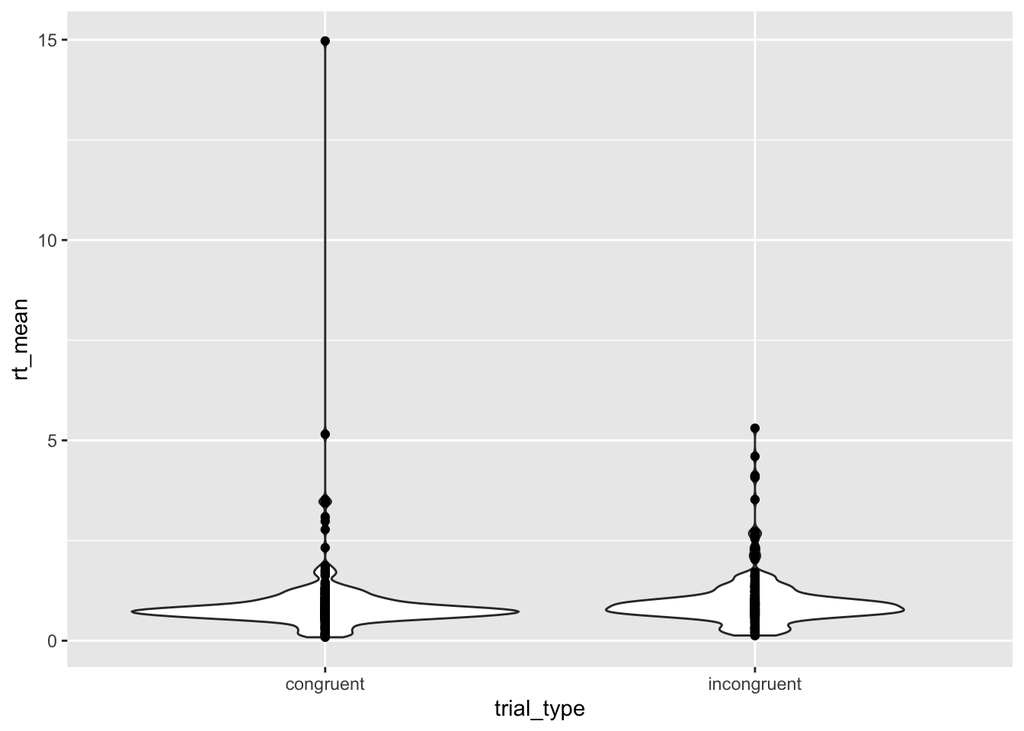

```r
ggplot(data=dd, aes(x=trial_type, y=rt_mean)) +
  geom_violin() +
  geom_point()
```

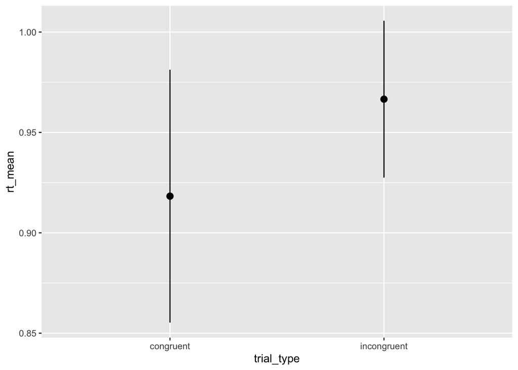

```r
ddd <- dd[,
         .(rt_mean = mean(rt_mean),
           rt_err = sd(rt_mean)/sqrt(.N)),
         .(trial_type)]

ggplot(data=ddd, aes(x=trial_type, y=rt_mean)) +
  geom_pointrange(aes(ymin=rt_mean-rt_err, ymax=rt_mean+rt_err))
```

```r
x <- dd[trial_type == 'incongruent', rt_mean]
y <- dd[trial_type == 'congruent', rt_mean]
t.test(x = x,
       y = y,
       alternative = c("greater"),
       mu = 0,
       paired = F,
       var.equal = T,
       conf.level = 0.95
)
```

```
##
##  Two Sample t-test
##
## data:  x and y
## t = 0.65195, df = 530, p-value = 0.2574
## alternative hypothesis: true difference in means is greater than 0
## 95 percent confidence interval:
##  -0.07378346         Inf
## sample estimates:
## mean of x mean of y
## 0.9665665 0.9182601
```

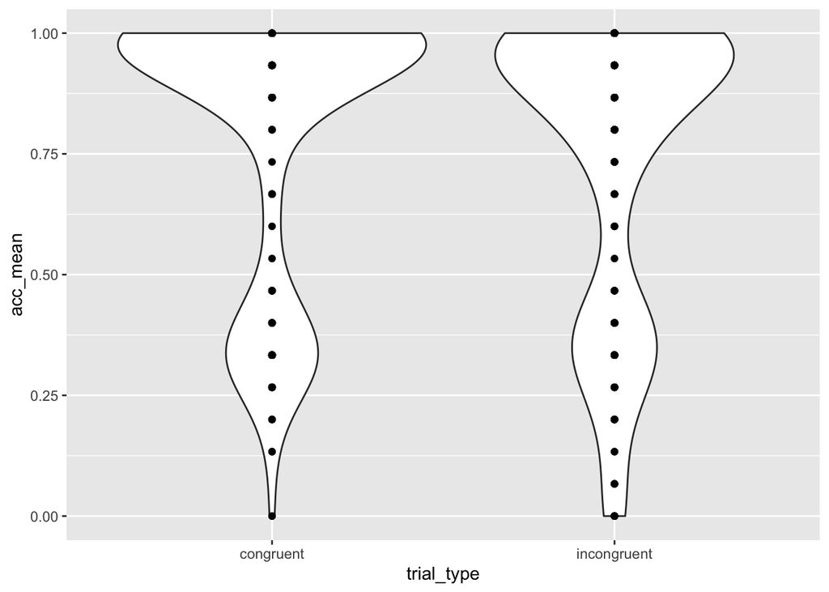

```r
## Notice below that now that we've got our equal sample
## size sorted out our standard error calculation is
## simplified.
nx <- length(x)
ny <- length(y)
n <- nx
sp_err = sqrt((var(x) + var(y)) / n)
t_obs = (mean(x) - mean(y)) / sp_err
df = 2*n - 2

## So at the end of the day here, it appears that we do not
## see significantly greater response times on incongruent
## trials as we do on congruent trials.

## Is this the replication crises in psychology??? Probably
## not. Check out the outliers in the congruent condition
## that will surely be influencing the estimated mean
## difference between these conditions. It would likely be
## quite sensible to remove these outliers from our
## analysis... however, doing so is slippery business and is
## beyond the scope of what I can do for you in this
## introductory unit.

##
##
## How do things turn out for accuracy?
## This is a simple matter of creating and then referencing
## a different column in the top level data.table, so I'll
## fly through this.
##
##
d[, acc := resp.keys == letterColor]
dd <- d[,
        .(acc_mean = mean(acc)),
        .(subject, trial_type)]

ggplot(data=dd, aes(x=trial_type, y=acc_mean)) +
  geom_violin() +
  geom_point()
```

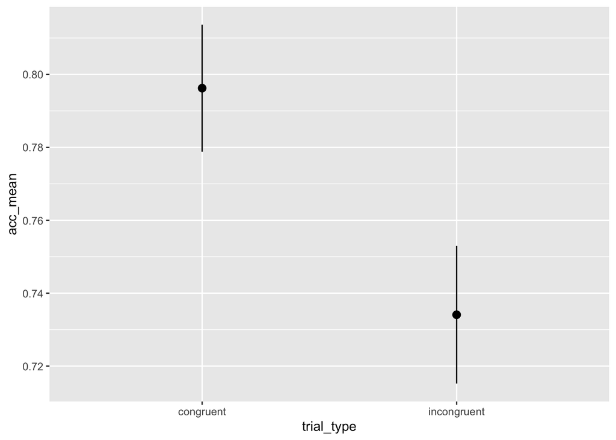

```r
ddd <- dd[,
         .(acc_mean = mean(acc_mean),
           acc_err = sd(acc_mean)/sqrt(.N)),
         .(trial_type)]

ggplot(data=ddd, aes(x=trial_type, y=acc_mean)) +
  geom_pointrange(aes(ymin=acc_mean-acc_err, ymax=acc_mean+acc_err))
```

```r
x <- dd[trial_type == 'incongruent', acc_mean]
y <- dd[trial_type == 'congruent', acc_mean]
t.test(x = x,
       y = y,
       alternative = c("less"),
       mu = 0,
       paired = F,
       var.equal = T,
       conf.level = 0.95
)
```

```
##
##  Two Sample t-test
##
## data:  x and y
## t = -2.4199, df = 530, p-value = 0.007929
## alternative hypothesis: true difference in means is less than 0
## 95 percent confidence interval:
##         -Inf -0.01983374
## sample estimates:
## mean of x mean of y
## 0.7340852 0.7962406
```

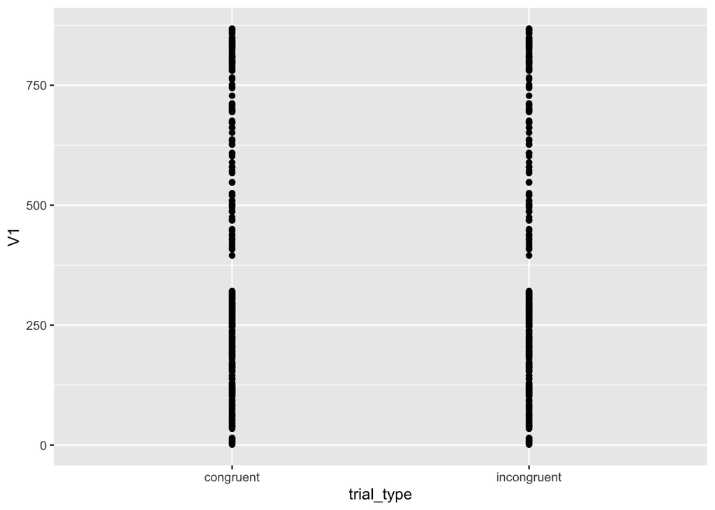

```r
nx <- length(x)
ny <- length(y)
n <- nx
sp_err = sqrt((var(x) + var(y)) / n)
t_obs = (mean(x) - mean(y)) / sp_err
df = 2*n - 2


##
##
## Ah, crap again. I just realised I forgot to figure out
## whether the factor we are examining (i.e., `trial_type`)
## is within- or between-subject. It's easy to see that it
## is a within-subjects factor. This means that it was not
## appropriate for us to apply an independent samples
## t-test! We should have done a paired samples t-test.
ddesigntype <- dd[, unique(subject), .(trial_type)]
ggplot(ddesigntype, aes(x=trial_type, y=V1)) +
  geom_point()
```

```r
##  Paired samples t-test for both accuracy and rt
dd <- d[,
        .(rt_mean = mean(resp.rt),
          acc_mean = mean(acc)),
        .(subject, trial_type)]

diff_scores = dd[, .(diff_scores_rt = diff(rt_mean),
                     diff_scores_acc = diff(acc_mean)),
                 .(subject)]


x <- diff_scores[, diff_scores_rt]
t.test(x = x,
       y = NULL,
       alternative = c("less"),
       mu = 0,
       paired = F,
       var.equal = T,
       conf.level = 0.95
)
```

```
##
##  One Sample t-test
##
## data:  x
## t = -2.0399, df = 265, p-value = 0.02118
## alternative hypothesis: true mean is less than 0
## 95 percent confidence interval:
##         -Inf -0.02301611
## sample estimates:
##  mean of x
## -0.1206218
```

```r
n <- length(x)
sp_err = sqrt((var(x)) / n)
t_obs = (mean(x)) / sp_err
df = n - 1

x <- diff_scores[, diff_scores_acc]
t.test(x = x,
       y = NULL,
       alternative = c("greater"),
       mu = 0,
       paired = F,
       var.equal = T,
       conf.level = 0.95
)
```

```
##
##  One Sample t-test
##
## data:  x
## t = 0.62469, df = 265, p-value = 0.2664
## alternative hypothesis: true mean is greater than 0
## 95 percent confidence interval:
##  -0.01317129         Inf
## sample estimates:
##  mean of x
## 0.00802005
```

```r
n <- length(x)
sp_err = sqrt((var(x)) / n)
t_obs = (mean(x)) / sp_err
df = n - 1

## Takeaway: If we do things correctly, then we aren't left
## wondering about the replication crises or how to deal
## with outliers. That is convenient, I suppose.


##
##
## Lets move on to another question. Does `letterColor`
## itself have an effect on response time? E.g., bull
## fighters use red flags to antagonise bulls... perhaps
## that will make people faster? Perhaps other colours have
## a similar or different effect?

## How many colours are there?
d[, unique(letterColor)]
```

```
## [1] "green" "blue"  "red"
```

```r
## Which colours belong to which group?
d[, unique(letterColor), .(group)]
```

```
##    group    V1
## 1:     I green
## 2:     I  blue
## 3:     I   red
## 4:    II   red
## 5:    II  blue
## 6:    II green
```

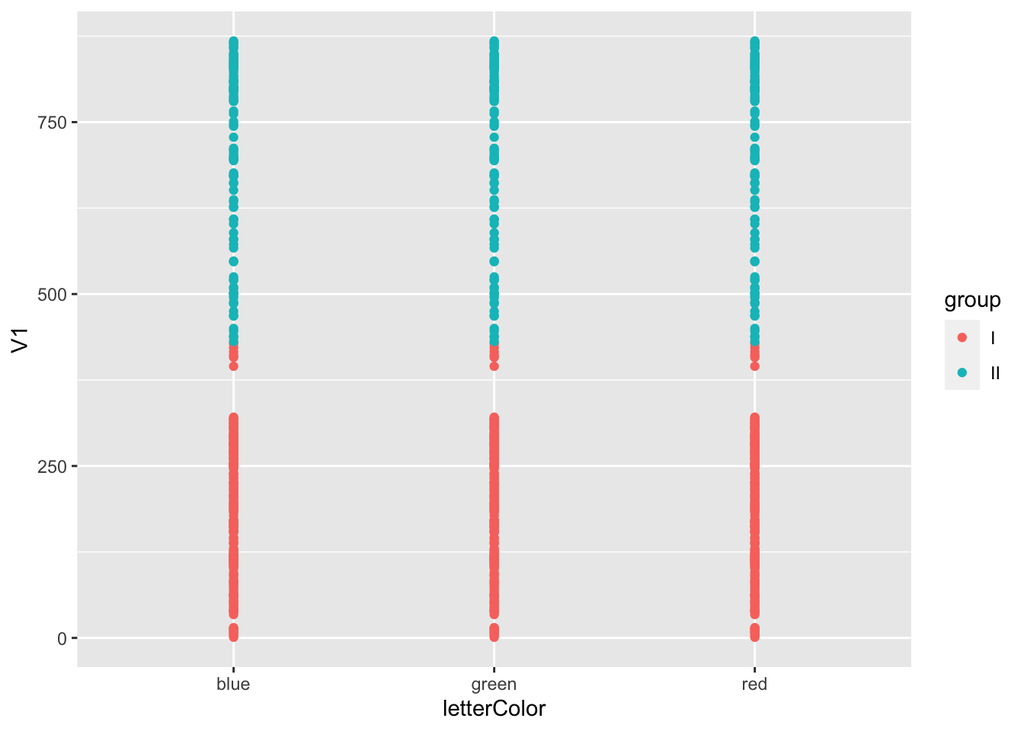

```r
## Which factors are within and which are between?
ddesigntype <- d[, unique(subject), .(letterColor, group)]
ggplot(data=ddesigntype, aes(x=letterColor, y=V1, colour=group)) +
  geom_point()
```

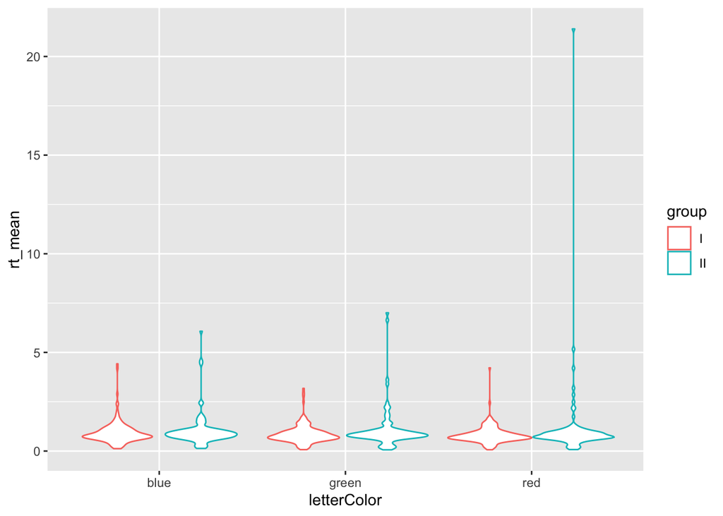

```r
## We can see that letterColor is within-subject and group
## is between-subject

## There are certainly more than two colours, so an ANOVA is
## the most appropriate of our tools to use.
dd <- d[,
        .(rt_mean = mean(resp.rt),
          acc_mean = mean(acc)),
        .(subject, letterColor, group)]

ggplot(data=dd, aes(x=letterColor, y=rt_mean, colour=group)) +
  geom_violin()
```

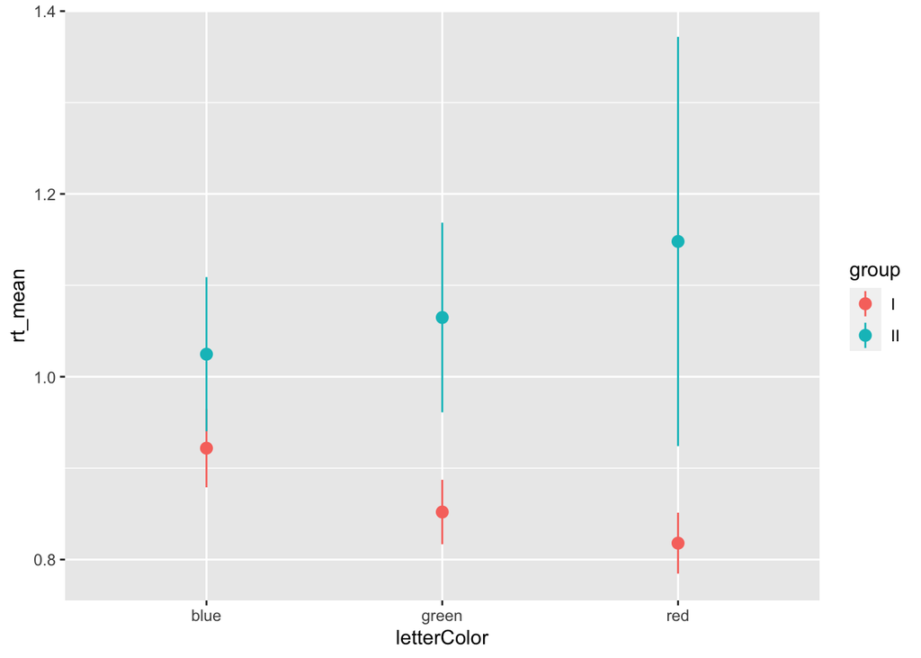

```r
ddd <- dd[,
         .(rt_mean = mean(rt_mean), rt_err = sd(rt_mean)/sqrt(.N)),
         .(letterColor, group)]

ggplot(data=ddd, aes(x=letterColor, y=rt_mean, colour=group)) +
  geom_pointrange(aes(ymin=rt_mean-rt_err, ymax=rt_mean+rt_err))
```

```r
ezANOVA(data=dd,
        dv=rt_mean,
        wid=subject,
        within=letterColor,
        between=group,
        type=3)
```

```
## $ANOVA
##              Effect DFn DFd          F          p p<.05          ges
## 2             group   1 264 5.87906144 0.01599363     * 0.0112623610
## 3       letterColor   2 528 0.05415247 0.94729292       0.0001001929
## 4 group:letterColor   2 528 1.14342151 0.31951455       0.0021113027
##
## $`Mauchly's Test for Sphericity`
##              Effect         W           p p<.05
## 3       letterColor 0.6199909 4.99657e-28     *
## 4 group:letterColor 0.6199909 4.99657e-28     *
##
## $`Sphericity Corrections`
##              Effect       GGe     p[GG] p[GG]<.05      HFe     p[HF] p[HF]<.05
## 3       letterColor 0.7246329 0.8969933           0.727584 0.8977502
## 4 group:letterColor 0.7246329 0.3061075           0.727584 0.3063013
```

```r
## First, the ANOVA results line up with the plot we made
## pretty well (main effect of group and not much else). For
## mixed designs, we haven't learned how to perform
## diagnostic checks (i.e., doing everything by hand) as we
## did above for the t-test, so we will leave it at this.
```

## Flanker experiment

Consider the experiment here:

- `https:/gitlab.pavlovia.org/demos/flanker`
- `https:/run.pavlovia.org/demos/flanker`

You should participate in the experiment to get a feel for it.

Reasonably cleaned data from this experiment can be found here:

- `https://crossley.github.io/cogs2020/data/real_data/data_flanker.csv`

`data_flanker.csv` contains the following columns:

- `subject`: participant indicator
- `stimulus`: the presented stimulus
- `condition`: whether the stimulus is congruent or incongruent
- `key_resp.keys`: the response made by the participant
- `response`: the correct response
- `key_resp.rt`: the response time of the key press
- `group`: the group or participants

```r
library(data.table)
library(ggplot2)
library(ez)

rm(list = ls())

## Load data_flanker.csv into a data.table
d <- fread('https://crossley.github.io/cogs2020/data/real_data/data_flanker.csv')

## For each of the questions listed below, make a diagnostic
## plot and perform an appropriate NHST. Perform the most
## robust sanity checks you can to be sure that the results
## you obtain from using built-in R functions are not
## corrupted by incorrect data wrangling, or otherwise
## slippery coding mistakes.

## The classic finding in a flanker experiment is that
## accuracy and reaction times are both better on congruent
## (e.g., `stimulus == '<<<<<'`) trials than on incongruent
## trials (e.g., `stimulus != '<<><<'`). Test this
## hypothesis using an appropriate t-test.

## Does the `group` a participant belongs to make a
## difference in overall accuracy or reaction time?

## Is there any difference in accuracy or reaction time
## between any combination of `group` and `condition`
## (congruent vs incongruent)?

## ## Is there any difference in accuracy or reaction time
## within the congruent stimuli? Within the inconruent
## stimuli?
```

## Visual search experiment

Consider the experiment here:

- `https:/gitlab.pavlovia.org/demos/visual-search`
- `https:/run.pavlovia.org/demos/visual-search`

You should participate in the experiment to get a feel for it.

Reasonably cleaned data from this experiment can be found here:

- `https://crossley.github.io/cogs2020/data/real_data/data_visual_search.csv`

`data_visual_search.csv` contains the following columns:

- `subject`: participant indicator
- `setSize`: number of stimuli on the screen
- `targetCol`: colour of the target image
- `distractorCol`: colour of the distractor images
- `mouse.time`: response time

```r
library(data.table)
library(ggplot2)
library(ez)

rm(list = ls())

## Load data_fla.csv into a data.table
d <- fread('https://crossley.github.io/cogs2020/data/real_data/data_visual_search.csv')

## For each of the questions listed below, make a diagnostic
## plot and perform an appropriate NHST. Perform the most
## robust sanity checks you can to be sure that the results
## you obtain from using built-in R functions are not
## corrupted by incorrect data wrangling, or otherwise
## slippery coding mistakes.

## Is the search time longer when the target is the same
## colour as the distractor images?

## Is the the search time longer when set size is bigger?

## Does the target colour have a bigger effect on search
## time at larger set sizes?
```

# Goal 2 practice

## 1.

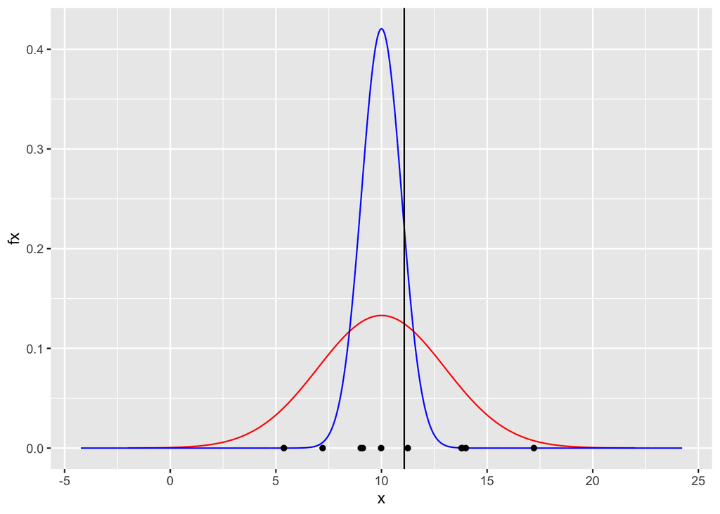

- Which distribution generated the observed raw data illustrated by the black dots?
- Which distribution generated the observed test statistic (i.e., the sample mean) illustrated by the black vertical line.
- What type of test does this figure illustrate?
  - `Normal test`
  - `t-test`
  - `Binomial test`
  - `ANOVA`
  - `None of the above`
  - `All of the above`
- What is the null hypothesis of this test?
- Define a specific alternative hypothesis compute the minimum sample size required required to generate a power of at least 0.8 and a type I error rate of 0.05. The population standard deviation of the random variable that generated the raw data is $\sigma_X = 3$.

## 2.

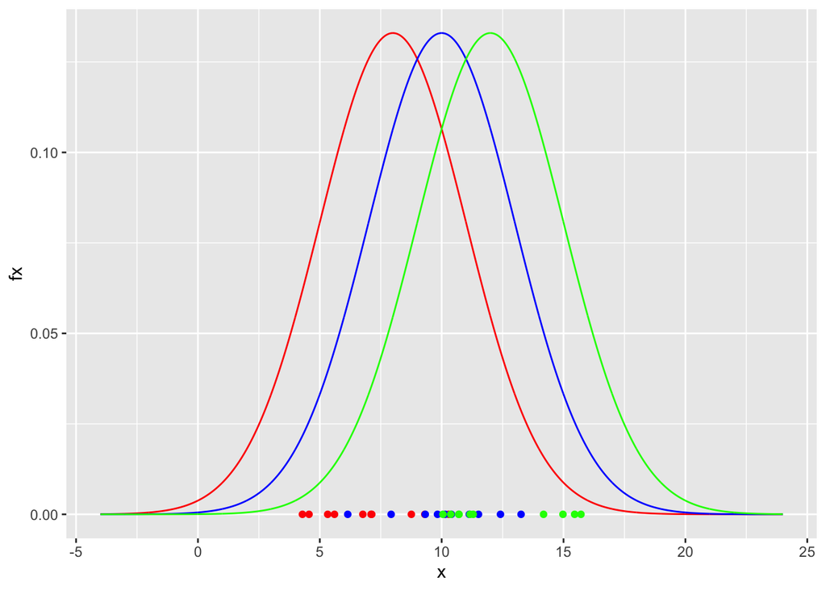

- The figure shows a plausible illustration of the alternative hypothesis for what NHST?
  - `Normal test`
  - `t-test`
  - `Binomial test`
  - `1-way ANOVA`
  - `None of the above`
  - `All of the above`
- Draw the sampling distribution of the test statistic given that there are 10 observations from each illustrated raw data distribution. Note that – while you are quite welcome to use `ggplot` to do this – it is also okay to simply draw by hand on a piece of paper. We won’t be looking at this point to mark you. It will be, however, an essential tool for you to know how to use on the exam.

## 3.

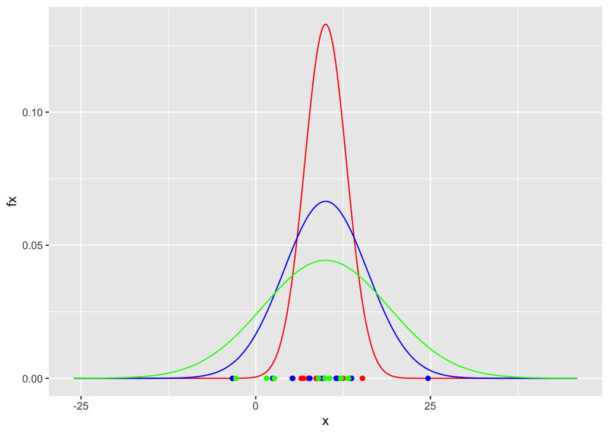

- Suppose that raw data is generated from the above distributions. Is this raw data consistent with the assumptions made in the null hypothesis of a 1-way ANOVA? If not, why?
- Suppose we were only interested in pairwise comparisons between the red, blue, and green random variables. Is the raw data consistent with the assumptions made in the null hypothesis of any t-test?

## 4.

- Consider a scenario where researchers are testing for significant differences between 2 treatments and 2 doses of each treatment in a fully between-subjects design. Draw the distributions for the raw data of a possible alternative hypothesis that shows a significant interaction but no main effects. Note that – while you are quite welcome to use `ggplot` to do this – it is also okay to simply draw by hand on a piece of paper. We won’t be looking at this point to mark you. It will be, however, an essential tool for you to know how to use on the exam.

# Goal 3 practice

## 1.

```r
d <- fread(
 'y treatment subject
  5.515427          A       1
  10.924246         A       2
  17.939227         A       3
  4.348122          A       4
  29.598741         A       5
  30.662101         A       6
  33.539774         A       7
  28.801510         A       8
  49.922370         B       9
  39.306065         B      10
  42.088254         B      11
  44.908764         B      12
  18.036523         B      13
  14.801655         B      14
  28.911145         B      15
  8.444655          B      16'
)
```

- Use an appropriate NHST to test for significant differences between treatment A and treatment B.
- Use another appropriate NHST to test for significant differences between treatment A and treatment B.
- Use an appropriate NHST to test if treatment A is significantly greater than treatment B.

## 2.

```r
d <- fread(
 'y treatment subject
  11.083774         A       1
  7.287537          A       2
  14.455723         A       3
  12.979903         A       4
  38.178090         A       5
  33.446377         A       6
  23.593767         A       7
  28.934277         A       8
  49.482699         B       1
  48.884316         B       2
  42.833022         B       3
  40.078597         B       4
  21.915287         B       5
  19.774314         B       6
  20.171760         B       7
  20.845134         B       8'
)
```

- Use an appropriate NHST to test for significant differences between treatment A and treatment B.
- Use another appropriate NHST to test for significant differences between treatment A and treatment B.
- Use an appropriate NHST to test if treatment A is significantly greater than treatment B.